[figure not shown]

### ESS 575 Models for Ecological Data

#### MCMC using Metropolis and Metropolis-Hastings Steps

#### February 28, 2019

#### Table of Contents

I. Introduction

II. Overview of the MCMC algorrithm

III. The Metropolis step

IV. The Metropolis-Hastings step

V. A toolbox for Metropolis-Hastings

The determinsitc model

Data simulation

Setup

The proposal function

The prior function

The likeliood function

The choose function

A plotting function

VI. Problem

#### I. Introduction

The purpose of this lab is to learn how Markov chain Monte Carlo (MCMC) algorithm approximate the marginal posterior distributions of parameters using accept-reject sampling implemented with Metropolis and Metropolis-Hastings steps. Accept-reject sampling is critical in ecology and social science because many of our most important models are non-linear. In these cases, Gibbs steps, which you used in the previous lab, will not work.

My goal in preparing this lab was to was to write math, code, and explanatory text that I wished I had when I struggled to learn this material. I have taught this lab a least a dozen times. One of the things I have learned is that students are usually poorly trained programmers and their inevitable programming errors interfere with a big picture, experiential understanding of MCMC. They get lost in the arcane details of debugging and wish that MCMC would just go away and leave them alone forever.

I am trying something different this time. I have provided a set of tested, general functions that can be easily modified for different problems and that provides a useful, instructional framework. The functions are not intended to be a bullet-proof package, but rather a general framework for implementing the MCMC sampling that can be tweaked (or crow-barred) to work for a broad range of problems. The functions in the toolbox provide a nice pedagogical construct for linking math, code, and concepts by creating a point of focus for different steps in Metropolis-Hastings algorithm using the light limitation of trees problem (from the likelihood lab) as an example.

The functions offers a a reasonable illustration of structured programming. This is a powerful approach that systems engineers and professional programers use all the time. The idea is to break all problems into a series of relatively small, tested functions and then assemble the functions to complete the overall task. If you find yourself writing a hundred lines of code without structuring your work into functions, then you are almost guaranteed to encounter nasty bugs. Professionals do it differently for a reason. Structured code is less prone to errors, easier to debug, and more transparent.

You must understand R functions and how they are invoked if you are to succeed in this lab. The concept of arguments and how they work is absolutely critical.

#### II. Overview of the MCMC algorrithm

We covered MCMC sampling in lecture and it would be good to have your notes open as you work through this handout. However the ideas are pretty simple. You need to begin by writing out the model and dissecting the full, model into a set of univariate, conditional distributions. The marginal posterior for each conditional distribution is estimated using the MCMC algorithm, as follows.

1. Set up a structure to store a “chain” of values for each parameter in a model. I like a list of arrays for this purpose but any multi-dimensional structure will do.
2. Pick a sensible starting value for each parameter and store it as the first element in each chain.
3. Choose an approach for sampling from the posterior distribution of each unobseved quantity. Exploit conjugate relationships whenever possible to allow you to sample *directly* from the posterior. Otherwise use an accept-reject methods like Metropolis or Metropolis-Hastings
4. Choose one of the parameters in your model to be the first one estimated. Which you choose doesn’t matter. Assuming that all of the other parameters are known and constant, make a random draw from the posterior distribution of the first parameter using its conditional distribution. Store the draw. Repeat this process for all of the parameters you seek to estimate, including those that quantify uncertainty.
5. When draws have been made from the posterior distribution of all parameters, go back to step 4). Repeat this process many times until the chains provide converged estimates of the shape of the posterior distribution. Estimates that have converged have the property that taking more samples would not change the posterior distribution, its mean, variance, kurtosis etc. Throw away the part of the chain that has not converged.
6. Use the converged portions of the stored chains to make inferences by calculating moments, densities, quantiles etc.

#### III. The Metropolis step

An MCMC algorithm is composed of a series of steps. In each step, we make a draw from the full conidtional distribution of an unobserved quantity, which is to say we make a draw assuming that all other unobserved quantities are known and constant. Many of these draws put together create a vector of each unobserved quantity. We then make inference using that vector (or vectors when we have multiple chains). You used Gibbs steps in the previoius lab to estimate a mean and a varince of normally distributed data exploiting conjugate relationships. Sometimes conjugates are not an option. In this case you will need to use accept-reject samplling The Metropolis algorithm is one way to accomplish that. It proceeds as follows. To simplify the language I will call all unobserved quantities “parameters”, but remember these could be latent quantities or dervied quantities.

1. Define the chain for the parameter as $\textbf{x}$ of length $n$. The first element in the $\mathbf{x}$ vector ($x_{1}$) is known because we chose it. The choice doesn’t matter much as long as we don’t pick something that is clearly silly–for example a negative integer for a parameter representing a survival probability.
2. Choose an new value $z$ from a proposal distribution. There are many ways to do this– we will learn one that works well and is easy to understand. We will define a proposal distribution, $q\left(z\vert x_{i},\sigma\right)$ as a probability density function for continuous parameters (a probability function for discrete parameters) that specifies the distribution the new value $z$ conditional on the current value of $x$ and a tuning parameter, $\sigma$. (For the Metropolis algorithm to work, these distributions must be symmetric – more about that in the next section). We choose the value of the tuning parameter to optimize the efficiency of the chain, but everything will still work (eventually) even if we make a sub-optimum choice (but not a ridiculous choice). How we choose values for $\sigma$ will be discussed later. So, the proposal distribution is centered on the current value–its mean, remembering, of course, that we may need to translate the mean and $\sigma$ into shape parameters appropriate for our choice of the type of proposal distribution. So the mean of the proposal distribution is $x_{i}$, and the parameter $\sigma$ determines how close the proposed, new value z is likely to be to $x_{i}$.

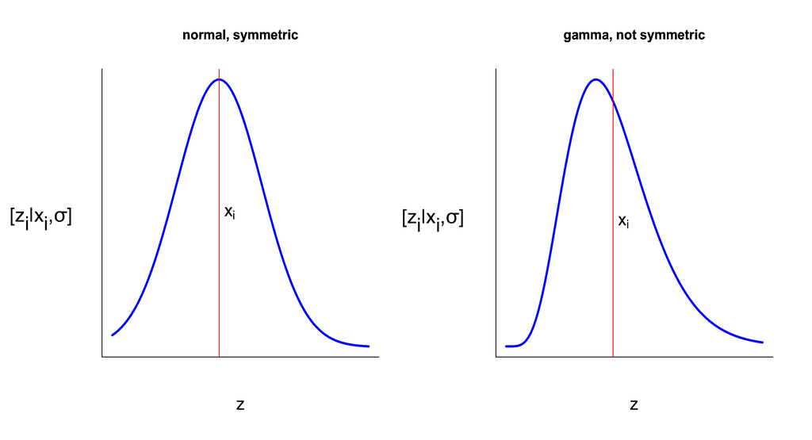

Figure 1. We make a draw of a proposed new value $z$ in the chain from a proposal distribution centered on the current value $x_i$.

3. Starting with the first value in the chain, we make a random draw from $q\left(z\vert x_{1},\sigma\right)$.
4. Now we want to decide, which should be kept in the chain (i.e., become $x_{2}$), the old value ($x_{1}$) or the shiny new one ($z$)? As explained in lecture, we do that with the ratio of the likelihoods multiplied by the priors for each of the two alternatives, $x_{1}$ and $z$,
   $$R_1=\frac{[\textbf{y}|z][z]}{[\textbf{y}|x_{1}][x_1]}.$$
   We keep $z$ (i.e, $x_{2}=z$) with probability $\min\left(R_{1},1\right)$ and we keep $x_{1}$ (i.e,. $x_{2}=x_{1}$) with probability $1-\min\left(R_{i},1\right)$. In practice (i.e. this lab) we will often use $R_i=\exp(\log([\textbf{y}|z][z]) - \log([\textbf{y}|x_{1}][x_1]))$. Why?
5. Increment $i$ and return to step 3. Repeat until a large number of samples have been chosen.
6. Use the samples collected after the chain has converged to make inferences about parameters and derived quantities of interest.

Students often ask, “Why is $z$ chosen probabilistically? Why is it possible to choose $z$ when $R_{i}<1$?” The reason is that failing to do so can mean that the chain gets “stuck” on a value of $x_{i}$ with high probability. This prevents us from learning about the shape of the distribution.

There are a couple of places it is easy to be confused. First, remember that $[\textbf{y}|z]$ and $[\textbf{y}| x_{i}]$ are likelihood functions using *all* of the data, just like the ones you programmed in the lab on likelihood – remember summing the log-likelihoods in a column. The likelihood functions may not be the same form as the proposal distribution, $q\left(z|x_{i}\right)$. Second, we usually need a model to “get the parameter into the likelihood”, that is, to make predictions that can be evaluated against data. So if our ecological model is $g(\mathbf{\theta})$, then the Metropolis acceptance ratio will be $R_{i}=\frac{[\textbf{y}|g(z)][z]}{[\textbf{y}|g(x_{i})][x_{i}]}$ where we are estimating one of the parameters in $\mathbf{\theta}$ and the others remain constant. If there are independent variables, these are implicitly included in $g(\mathbf{\theta})$.

#### IV. The Metropolis-Hastings step

There is an important caveat about the Metropolis algorithm: the proposal distribution must be symmetric, which means that $q(z|x_{i},\sigma)=q(x_{i}|z,\sigma)$.This is a very simple idea which says that if the current value of the chain is $x_{i}$, the probability of drawing $z$ is equal to the probability of drawing $x_{i}$ if the chain is located at $z$.

*Exercise*: Calculate the probability density random variable $z$=10, from a normal distribution with mean $\mu=x_{i}=12$ and standard deviation $\sigma=1.5$. Now calculate the density of a normally distributed random variable $x_{i}=12$ with mean $\mu=z=10$ and standard deviation $\sigma=1.5$ . Repeat this calculation for a gamma distribution (using moment matching, of course). Which distribution is symmetric? Think of another proposal distribution that is symmetric and one that is asymmetric. Could you use the Poisson for a proposal distribution for continuous parameters? What would be the problem with doing so? An important point–just because a distribution appears to be symmetric (shaped like a normal) doesn’t mean that it is. It must satisfy the equality $q(z|x_{i},\sigma)=q(x_{i}|z,\sigma)$

There are many cases when a symmetric proposal distribution works fine. But we run into problems if the distribution includes values that are not defined for the parameter, as will be the case with a normal proposal distribution if our parameter is strictly positive. In that case, we can make a draw from the normal, exponentiate it to keep it positive, and merrily use Metropolis.This is fondly known to students at CSU as the Hooten shuffle. It is one of his favorite tricks.

Hastings (1970) showed that a very small adjustment to the calculation of $R_{i}$ relaxes the assumption that proposal distributions are symmetric. In the Metropolis-Hastings algorithm, we use
$$R_{i}=\frac{[\textbf{y}|z][z]}{[\textbf{y}|x_{i}][x_{i}]}\cdot\frac{q\left(x_{i}|z,\sigma\right)}{q\left(z\vert x_{i},\sigma\right)}$$
and use the same decision process to decide on the value of x_{i+1}. Be sure that you understand that the quantity $\frac{q\left(x_{i}|z,\sigma\right)}{q\left(z\vert x_{i},\sigma\right)}$ is the ratio of the *probability densities* (or probabilities for discrete parameters) returned by the distribution $q$ and is not a new draw from the distributions. (This confusion has cause untold agony in past MCMC labs.)

I favor using Metropolis-Hastings for everything where Gibbs steps can’t be used. When the proposal distributions are symmetric, $\frac{q\left(x_{i}|z,\sigma\right)}{q\left(z\vert x_{i},\sigma\right)}=1$, reducing the algorithm to Metropolis. By using Metropolis-Hastings for all proposal distributions, symmetric and asymmetric, I can have one set of code that applies in a general way to many problems, without having to worry about forgetting to include $\frac{q\left(x_{i}|z,\sigma\right)}{q\left(z\vert x_{i},\sigma\right)}$ for asymmetric distributions (another source of potential agony). Which brings us to the next topic, coding Metropolis-Hastings.

#### V. A toolbox for Metropolis-Hastings

I wrote some code for the light limitation of trees problem that you worked on in the likelihood lab. The deterministic model is
$$\mu_{i}=g(\alpha,\gamma,c,L_i)=\frac{\alpha(L_i-c)}{\frac{\alpha}{\gamma}+(L_i-c)}$$
. We want to approximate the marginal posterior distributions of the parameters $\alpha,\gamma,c$, and $\sigma$, all of which are continuous and strictly positive. The growth rate is a real number that can be positive or negative. We have no prior knowledge of any of the parameters.Note that the light level for the $i^{th}$ tree is notated as $L_i$. We are assuming it is observed witout error. The posterior and joint distribution is
$$[\alpha,\gamma,c,\sigma|\textbf{y}]\propto\prod\limits _{i=1}^n[y_i|g(\alpha,\gamma,c,L_i,\sigma)[\alpha][\gamma][c][\sigma]$$

Before we get going, a bit of rationale for this exercise. You could estimate these parameters in a quick snap with one line of code in R using the `nls( )` function. Why bother with the pain of doing it by MCMC? The answer is that you can use MCMC for problems that would swiftly bring `nls()` to its knees. In the spirit of walking before running, we will learn MCMC using a simple model, but our learning will allow us to analyze much more complex ones that can be solved virtually no other way. Ok, Ok, there is also INLA but that is beyond the scope of the class. Moreover, as you will see, we will estimate the posterior distribution of some derived parameters, a impossible task with canned routines like `nls(`). Finally, the last time I checked, there was no easy way to get confidence bands on the predictions from `nls()`.

*Exercise*: What is a reasonable distribution to use for the likelihood? For the priors? For the proposal distribution?

*Exercise*: Write the full conditioal distributions for all of the parameters.

Study the code for the functions that follow. Your challenge will be to use these functions to construct a MCMC algorithm using Metropolis-Hastings steps.